# QA: NLI Model Benchmark

Held-out evaluation across the zero-shot baseline and every fine-tuned checkpoint

Published

September 29, 2026

## What this measures, and what it does not

**It measures agreement with `gpt-4o-mini`.** Every label in the holdout comes from Phase 2’s grounded, quote-checked LLM verdict. Fine-tuning distils that judgment into the NLI model and this report scores how well the distillation worked. It does not measure truth: the LLM’s verdicts have never been checked against human labels. That is a ceiling, not a flaw — distilling an expensive accurate judge into a cheap one is the point — but every number below inherits it.

Design and reasoning: TD_NLI_training.

Holdout composition and leakage diagnostics

| Property | Value |
| --- | --- |
| benchmark salt | bench-v1 |
| holdout fraction | 0.2 |
| grouping key | assessment + bm (km deliberately omitted – one BM spans several KMs) |
| train rows | 3590 |
| test rows | 1205 |
| train groups | 83 |
| test groups | 19 |
| claims in BOTH folds | 0 |
| works in both folds | 135 of 2243 (6.0%) |
| test rows involving a shared work | 422 (35.0%) |

**`claims in BOTH folds` must be 0.** The holdout is grouped by `(assessment, bm)` — deliberately *without* `km`, because one Background Message belongs to several Key Messages and carries byte-identical claim text under each. Grouping on `(assessment, km, bm)` looked tighter and was measurably leakier: 141 groups, 126 claim strings present in both folds. If this number is ever non-zero, the grouping key has drifted.

**Work overlap is reported, not eliminated.** A work cited under several BMs can appear on both sides paired with *different* claims. That is much weaker than claim-text leakage — the model sees the premise, never the pair or its label — and closing it needs a connected-component split that at this size yields a few huge unbalanced components, trading a small measurable bias for a large unmeasurable one. Judge the headline numbers with the percentage above in mind.

## Models under test

Scored models. `zeroshot` = 3 forward passes per row with the deployed hypothesis template, entailment logits cross-normalised. `direct` = the fine-tuned head’s own 3-way softmax. `split_aware` is NA for the untrained baseline.

| model_id | mode | split_aware | max_length | n_rows | n_truncated |
| --- | --- | --- | --- | --- | --- |
| bge-m3-zeroshot-v2.0-c | zeroshot | NA | 2048 | 1205 | 3 |
| KP=GA1_citing=GA1_downsample_seed=13_date=2026.09.29_14_48 | direct | TRUE | 512 | 1205 | 257 |
| KP=GA1_IAS_citing=GA1_downsample_seed=13_date=2026.09.01_11_30 | direct | FALSE | 512 | 1205 | 257 |
| KP=GA1_IAS_citing=GA1_downsample_seed=13_date=2026.09.01_13_20 | direct | FALSE | 512 | 1205 | 257 |
| KP=GA1_IAS_TCA_VA_citing=GA1_downsample_seed=13_date=2026.09.28_15_26 | direct | TRUE | 512 | 1205 | 257 |
| KP=GA1_IAS_TCA_VA_citing=GA1_downsample_seed=13_date=2026.09.28_19_15 | direct | TRUE | 512 | 1205 | 257 |

**Important`split_aware = FALSE` means the scores below are contaminated**

A checkpoint trained **before** the holdout existed was trained on rows drawn from the whole pool — including what is now the test fold. Its score here is recall on memorised rows, not generalisation.

Those runs are shown rather than hidden, because they are the clearest available evidence for *how badly a leaking split flatters a model* — which is the finding that motivated this benchmark. But **no table below is a ranking**. Compare only rows where `split_aware` is `TRUE` against the baseline.

One asymmetry that runs the other way, and makes the honest result conservative: the fine-tuned models are scored at the 512 tokens they were trained on, and 141 of 467 premises (30%) hit that limit, against 3 for the baseline at its deployed 2048. The fine-tuned models are working from truncated abstracts where the baseline is not.

The baseline is scored the way it is actually **deployed** — a binary entailment head cannot emit SUPPORTS/REFUTES/NEI directly, so each candidate label is folded into its own reformulated hypothesis and the three entailment logits are cross-normalised. A baseline scored differently from how it runs in production is not a baseline.

One caveat on exactness: the deployed pipeline cleans the premise (`clean_title()`/`clean_abstract()` strip HTML/JATS/LaTeX) while this benchmark uses raw `title`/`abstract`, matching what `train_nli.py` trains on. Spot-checked against real deployed scores, local and production probabilities agree to ~4 decimal places on clean abstracts and diverge on marked-up ones.

## The headline: SUPPORTS → REFUTES recovery

60% of every confirmed refutation in this corpus is a pair the zero-shot model called **SUPPORTS** and the LLM overturned. It did not merely miss them — it got them backwards. So the question that decides whether fine-tuning did this project’s job is: of the holdout rows where NLI said SUPPORTS and the truth is REFUTES, how many does each model now call REFUTES?

Rows where NLI said SUPPORTS and the truth is REFUTES. Read only the split_aware = TRUE rows against the baseline (NA).

| model_id | split_aware | n_subset | n_recovered | recovery_rate |
| --- | --- | --- | --- | --- |
| KP=GA1_IAS_citing=GA1_downsample_seed=13_date=2026.09.01_13_20 | FALSE | 127 | 115 | 90.6% |
| KP=GA1_IAS_TCA_VA_citing=GA1_downsample_seed=13_date=2026.09.28_15_26 | TRUE | 127 | 115 | 90.6% |
| KP=GA1_citing=GA1_downsample_seed=13_date=2026.09.29_14_48 | TRUE | 127 | 85 | 66.9% |
| KP=GA1_IAS_TCA_VA_citing=GA1_downsample_seed=13_date=2026.09.28_19_15 | TRUE | 127 | 82 | 64.6% |
| KP=GA1_IAS_citing=GA1_downsample_seed=13_date=2026.09.01_11_30 | FALSE | 127 | 40 | 31.5% |
| bge-m3-zeroshot-v2.0-c | NA | 127 | 15 | 11.8% |

A checkpoint that does not move this number has not earned deployment, whatever its macro-F1 says.

## Per-class performance

Accuracy is deliberately absent. The holdout is near-balanced while deployment is 0.2–3% REFUTES, so a balanced-set accuracy flatters every model equally and predicts nothing about the real stream. REFUTES precision and recall are given separately and never folded into F1 for the headline: a missed refutation is a finding that never surfaces, a false one is a claim a human discards in seconds, and F1 assumes those cost the same.

| model_id | split_aware | label | precision | recall | f1 | support |
| --- | --- | --- | --- | --- | --- | --- |
| KP=GA1_IAS_TCA_VA_citing=GA1_downsample_seed=13_date=2026.09.28_15_26 | TRUE | NOT_ENOUGH_INFO | 88.6% | 61.2% | 72.4% | 510 |
| KP=GA1_IAS_TCA_VA_citing=GA1_downsample_seed=13_date=2026.09.28_19_15 | TRUE | NOT_ENOUGH_INFO | 90.7% | 67.3% | 77.3% | 510 |
| KP=GA1_IAS_citing=GA1_downsample_seed=13_date=2026.09.01_11_30 | FALSE | NOT_ENOUGH_INFO | 76.7% | 66.7% | 71.4% | 510 |
| KP=GA1_IAS_citing=GA1_downsample_seed=13_date=2026.09.01_13_20 | FALSE | NOT_ENOUGH_INFO | 86.9% | 73.1% | 79.4% | 510 |
| KP=GA1_citing=GA1_downsample_seed=13_date=2026.09.29_14_48 | TRUE | NOT_ENOUGH_INFO | 86.7% | 71.6% | 78.4% | 510 |
| bge-m3-zeroshot-v2.0-c | NA | NOT_ENOUGH_INFO | 16.8% | 6.3% | 9.1% | 510 |
| KP=GA1_IAS_TCA_VA_citing=GA1_downsample_seed=13_date=2026.09.28_15_26 | TRUE | REFUTES | 28.8% | 90.0% | 43.6% | 220 |
| KP=GA1_IAS_TCA_VA_citing=GA1_downsample_seed=13_date=2026.09.28_19_15 | TRUE | REFUTES | 42.4% | 66.4% | 51.8% | 220 |
| KP=GA1_IAS_citing=GA1_downsample_seed=13_date=2026.09.01_11_30 | FALSE | REFUTES | 39.8% | 47.7% | 43.4% | 220 |
| KP=GA1_IAS_citing=GA1_downsample_seed=13_date=2026.09.01_13_20 | FALSE | REFUTES | 44.7% | 90.0% | 59.7% | 220 |
| KP=GA1_citing=GA1_downsample_seed=13_date=2026.09.29_14_48 | TRUE | REFUTES | 40.2% | 64.5% | 49.6% | 220 |
| bge-m3-zeroshot-v2.0-c | NA | REFUTES | 57.9% | 35.0% | 43.6% | 220 |
| KP=GA1_IAS_TCA_VA_citing=GA1_downsample_seed=13_date=2026.09.28_15_26 | TRUE | SUPPORTS | 75.2% | 26.1% | 38.8% | 475 |
| KP=GA1_IAS_TCA_VA_citing=GA1_downsample_seed=13_date=2026.09.28_19_15 | TRUE | SUPPORTS | 73.9% | 75.2% | 74.5% | 475 |
| KP=GA1_IAS_citing=GA1_downsample_seed=13_date=2026.09.01_11_30 | FALSE | SUPPORTS | 57.8% | 60.6% | 59.2% | 475 |
| KP=GA1_IAS_citing=GA1_downsample_seed=13_date=2026.09.01_13_20 | FALSE | SUPPORTS | 82.9% | 58.1% | 68.3% | 475 |
| KP=GA1_citing=GA1_downsample_seed=13_date=2026.09.29_14_48 | TRUE | SUPPORTS | 74.5% | 67.6% | 70.9% | 475 |
| bge-m3-zeroshot-v2.0-c | NA | SUPPORTS | 37.2% | 69.1% | 48.3% | 475 |

Confusion matrix: rows = LLM verdict (truth), columns = model prediction

| model_id | label | NOT_ENOUGH_INFO | REFUTES | SUPPORTS |
| --- | --- | --- | --- | --- |
| KP=GA1_IAS_TCA_VA_citing=GA1_downsample_seed=13_date=2026.09.28_15_26 | NOT_ENOUGH_INFO | 312 | 168 | 30 |
| KP=GA1_IAS_TCA_VA_citing=GA1_downsample_seed=13_date=2026.09.28_15_26 | REFUTES | 11 | 198 | 11 |
| KP=GA1_IAS_TCA_VA_citing=GA1_downsample_seed=13_date=2026.09.28_15_26 | SUPPORTS | 29 | 322 | 124 |
| KP=GA1_IAS_TCA_VA_citing=GA1_downsample_seed=13_date=2026.09.28_19_15 | NOT_ENOUGH_INFO | 343 | 93 | 74 |
| KP=GA1_IAS_TCA_VA_citing=GA1_downsample_seed=13_date=2026.09.28_19_15 | REFUTES | 22 | 146 | 52 |
| KP=GA1_IAS_TCA_VA_citing=GA1_downsample_seed=13_date=2026.09.28_19_15 | SUPPORTS | 13 | 105 | 357 |
| KP=GA1_IAS_citing=GA1_downsample_seed=13_date=2026.09.01_11_30 | NOT_ENOUGH_INFO | 340 | 49 | 121 |
| KP=GA1_IAS_citing=GA1_downsample_seed=13_date=2026.09.01_11_30 | REFUTES | 26 | 105 | 89 |
| KP=GA1_IAS_citing=GA1_downsample_seed=13_date=2026.09.01_11_30 | SUPPORTS | 77 | 110 | 288 |
| KP=GA1_IAS_citing=GA1_downsample_seed=13_date=2026.09.01_13_20 | NOT_ENOUGH_INFO | 373 | 94 | 43 |
| KP=GA1_IAS_citing=GA1_downsample_seed=13_date=2026.09.01_13_20 | REFUTES | 8 | 198 | 14 |
| KP=GA1_IAS_citing=GA1_downsample_seed=13_date=2026.09.01_13_20 | SUPPORTS | 48 | 151 | 276 |
| KP=GA1_citing=GA1_downsample_seed=13_date=2026.09.29_14_48 | NOT_ENOUGH_INFO | 365 | 86 | 59 |
| KP=GA1_citing=GA1_downsample_seed=13_date=2026.09.29_14_48 | REFUTES | 27 | 142 | 51 |
| KP=GA1_citing=GA1_downsample_seed=13_date=2026.09.29_14_48 | SUPPORTS | 29 | 125 | 321 |
| bge-m3-zeroshot-v2.0-c | NOT_ENOUGH_INFO | 32 | 38 | 440 |
| bge-m3-zeroshot-v2.0-c | REFUTES | 29 | 77 | 114 |
| bge-m3-zeroshot-v2.0-c | SUPPORTS | 129 | 18 | 328 |

## Threshold sweep

Phase 1 stores the full probability distribution and every threshold decision is made downstream in `dplyr`, so a single argmax operating point would describe neither the model nor the deployment. Framed as a REFUTES detector — predict REFUTES iff `p_refutes >= t` — which is what these scores are actually used for. This is also where the re-calibrated deployment threshold comes from: the base-rate shift between a balanced training fold and a 0.2% deployment stream guarantees an argmax classifier over-predicts REFUTES in production.

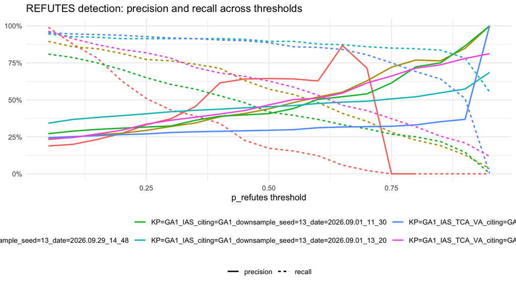

## Per assessment

558 of 562 REFUTES in the pool come from GA1 and IAS, so a pooled number mostly measures those two. TCA and VA are shown separately even though their counts are tiny — “we cannot tell” is a legitimate and useful result, and whether anything learned here generalises beyond GA1/IAS is an open question.

| model_id | assessment | n | n_refutes | refutes_recall | refutes_precision |
| --- | --- | --- | --- | --- | --- |
| KP=GA1_IAS_TCA_VA_citing=GA1_downsample_seed=13_date=2026.09.28_15_26 | GA1 | 961 | 187 | 93.6% | 27.3% |
| KP=GA1_IAS_TCA_VA_citing=GA1_downsample_seed=13_date=2026.09.28_19_15 | GA1 | 961 | 187 | 68.4% | 41.0% |
| KP=GA1_IAS_citing=GA1_downsample_seed=13_date=2026.09.01_11_30 | GA1 | 961 | 187 | 46.0% | 37.9% |
| KP=GA1_IAS_citing=GA1_downsample_seed=13_date=2026.09.01_13_20 | GA1 | 961 | 187 | 90.4% | 42.5% |
| KP=GA1_citing=GA1_downsample_seed=13_date=2026.09.29_14_48 | GA1 | 961 | 187 | 62.6% | 40.6% |
| bge-m3-zeroshot-v2.0-c | GA1 | 961 | 187 | 33.7% | 58.3% |
| KP=GA1_IAS_TCA_VA_citing=GA1_downsample_seed=13_date=2026.09.28_15_26 | IAS | 221 | 33 | 69.7% | 65.7% |
| KP=GA1_IAS_TCA_VA_citing=GA1_downsample_seed=13_date=2026.09.28_19_15 | IAS | 221 | 33 | 54.5% | 69.2% |
| KP=GA1_IAS_citing=GA1_downsample_seed=13_date=2026.09.01_11_30 | IAS | 221 | 33 | 57.6% | 76.0% |
| KP=GA1_IAS_citing=GA1_downsample_seed=13_date=2026.09.01_13_20 | IAS | 221 | 33 | 87.9% | 85.3% |
| KP=GA1_citing=GA1_downsample_seed=13_date=2026.09.29_14_48 | IAS | 221 | 33 | 75.8% | 43.9% |
| bge-m3-zeroshot-v2.0-c | IAS | 221 | 33 | 42.4% | 56.0% |
| KP=GA1_IAS_TCA_VA_citing=GA1_downsample_seed=13_date=2026.09.28_15_26 | TCA | 10 | 0 | – | 0.0% |
| KP=GA1_IAS_TCA_VA_citing=GA1_downsample_seed=13_date=2026.09.28_19_15 | TCA | 10 | 0 | – | 0.0% |
| KP=GA1_IAS_citing=GA1_downsample_seed=13_date=2026.09.01_11_30 | TCA | 10 | 0 | – | 0.0% |
| KP=GA1_IAS_citing=GA1_downsample_seed=13_date=2026.09.01_13_20 | TCA | 10 | 0 | – | 0.0% |
| KP=GA1_citing=GA1_downsample_seed=13_date=2026.09.29_14_48 | TCA | 10 | 0 | – | 0.0% |
| bge-m3-zeroshot-v2.0-c | TCA | 10 | 0 | – | – |
| KP=GA1_IAS_TCA_VA_citing=GA1_downsample_seed=13_date=2026.09.28_15_26 | VA | 13 | 0 | – | 0.0% |
| KP=GA1_IAS_TCA_VA_citing=GA1_downsample_seed=13_date=2026.09.28_19_15 | VA | 13 | 0 | – | – |
| KP=GA1_IAS_citing=GA1_downsample_seed=13_date=2026.09.01_11_30 | VA | 13 | 0 | – | 0.0% |
| KP=GA1_IAS_citing=GA1_downsample_seed=13_date=2026.09.01_13_20 | VA | 13 | 0 | – | 0.0% |
| KP=GA1_citing=GA1_downsample_seed=13_date=2026.09.29_14_48 | VA | 13 | 0 | – | 0.0% |
| bge-m3-zeroshot-v2.0-c | VA | 13 | 0 | – | – |

## What this cannot tell you

**Recall against the real corpus.** The holdout inherits Phase 2’s routing bias: for citing works only `REFUTES-certain` and `SUPPORTS-certain` pairs were ever sent for LLM review, so refutations hiding among the 1.23M `NOT_ENOUGH_INFO` pairs in GA1 alone are in no fold of any split. The full-coverage key-paper chain estimates 0.37% of NEI pairs are genuine refutations against 3.09% of REFUTES pairs — an 8x enrichment across a 4.8x larger pile, meaning **37% of the refutations found there were sitting in the NEI bucket**. Every number above is conditional on a pair having been routed for review in the first place.

Closing that needs a recall probe: a random sample across the full NLI output including NEI, labelled by Phase 2. See TD_NLI_training.